# Walmart-Sales-Forecast

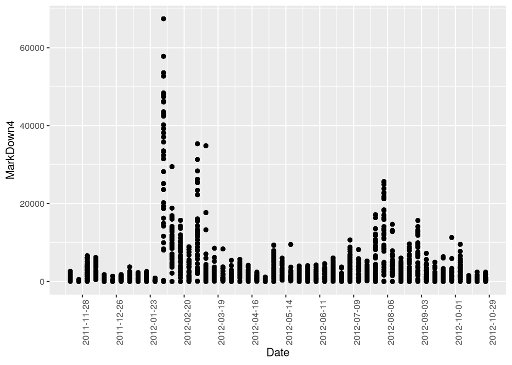

```r
MKD %>% ggplot(aes(x = Date, y = MarkDown4))+ geom_point()+scale_x_date(date_breaks = "4 weeks")+ theme(axis.text.x = element_text(angle = 90, hjust = 1))
```

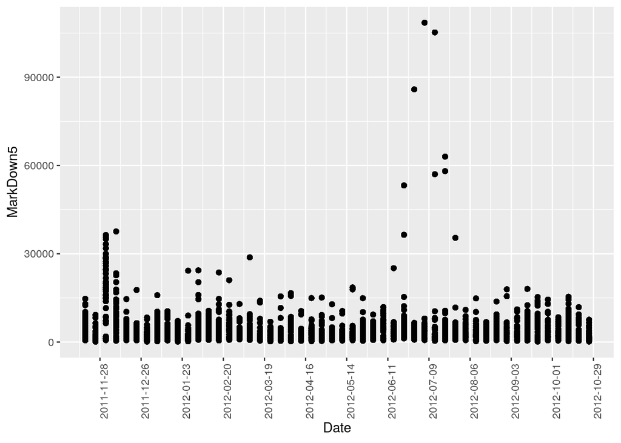

```r
MKD %>% ggplot(aes(x = Date, y = MarkDown5))+ geom_point()+scale_x_date(date_breaks = "4 weeks")+ theme(axis.text.x = element_text(angle = 90, hjust = 1))
```

Correlations between MarkDowns and Weekly Sales after 2011-11-18

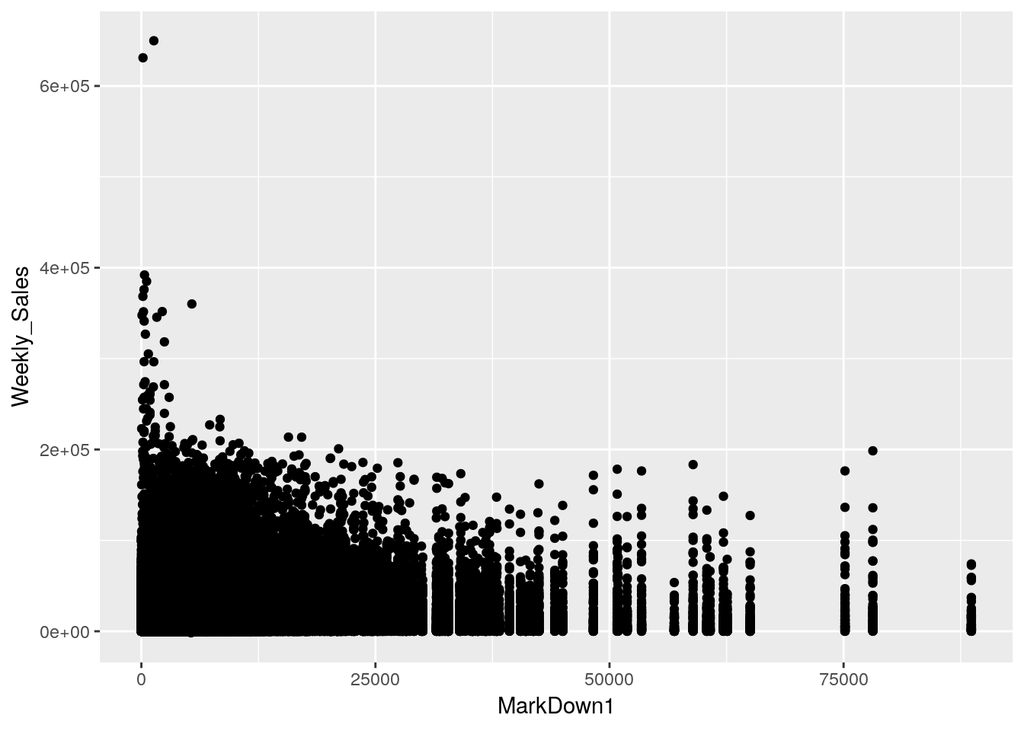

```r
SM<-alldata %>% dplyr::select (Date, Weekly_Sales, MarkDown1, MarkDown2, MarkDown3, MarkDown4, MarkDown5) %>%
  filter (Date >= "2011-11-18")
ggplot(SM, aes(x=MarkDown1, y = Weekly_Sales)) + geom_point()
```

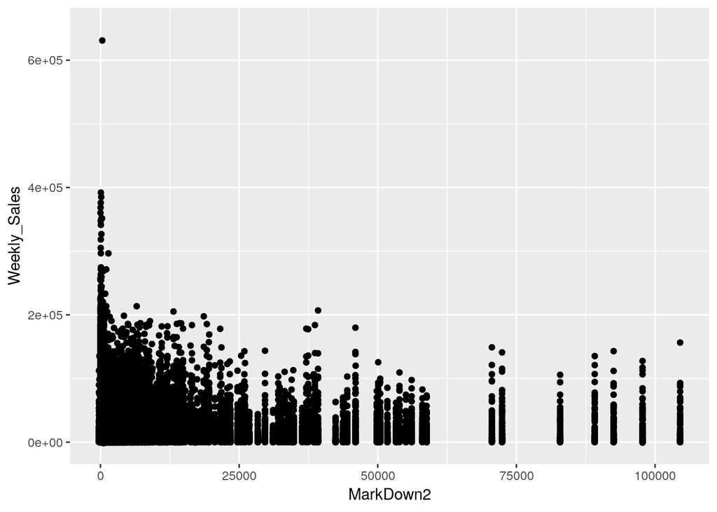

```r
ggplot(SM, aes(x = MarkDown2, y = Weekly_Sales)) + geom_point()
```

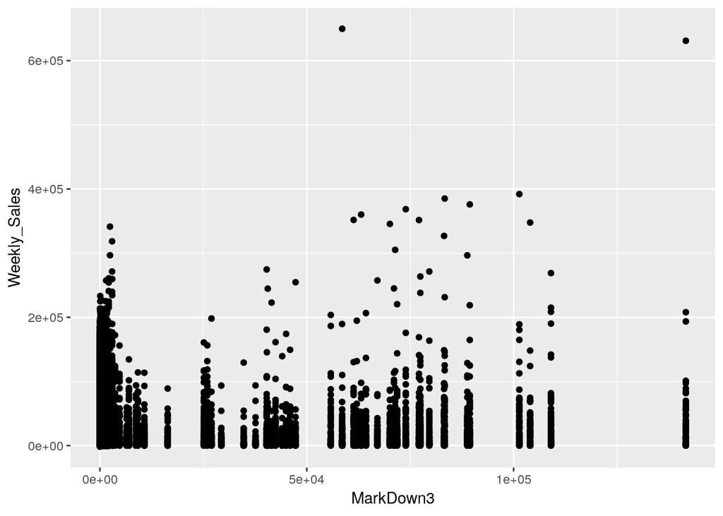

```r
ggplot(SM, aes(x = MarkDown3, y = Weekly_Sales)) + geom_point()
```

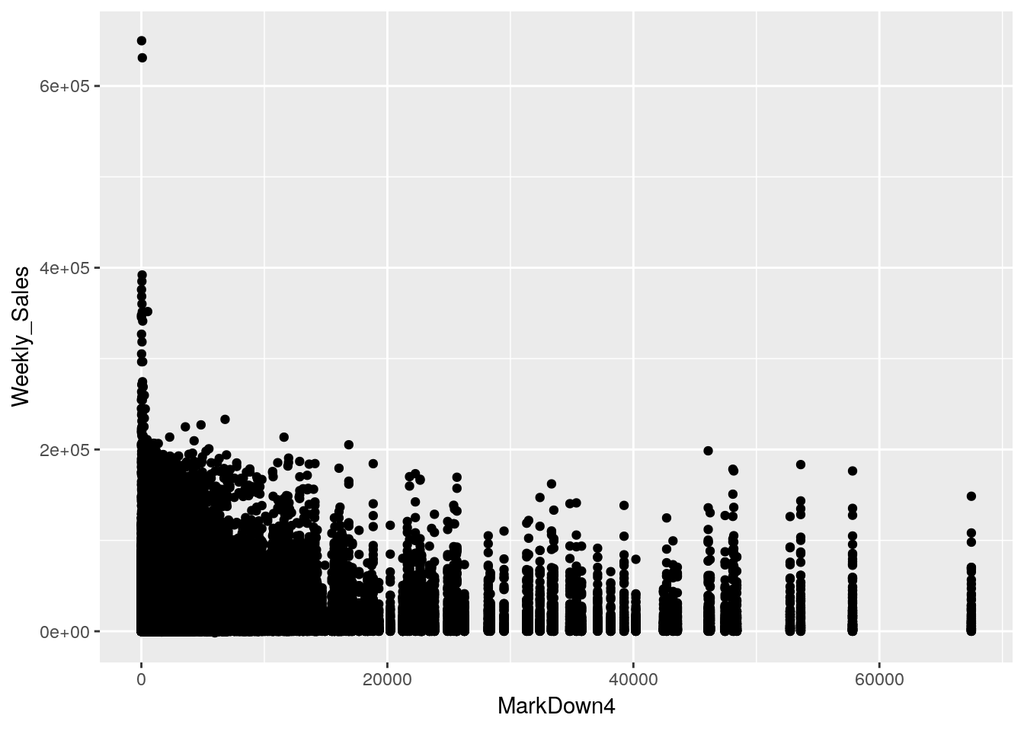

```r
ggplot(SM, aes(x= MarkDown4, y = Weekly_Sales))+geom_point()
```

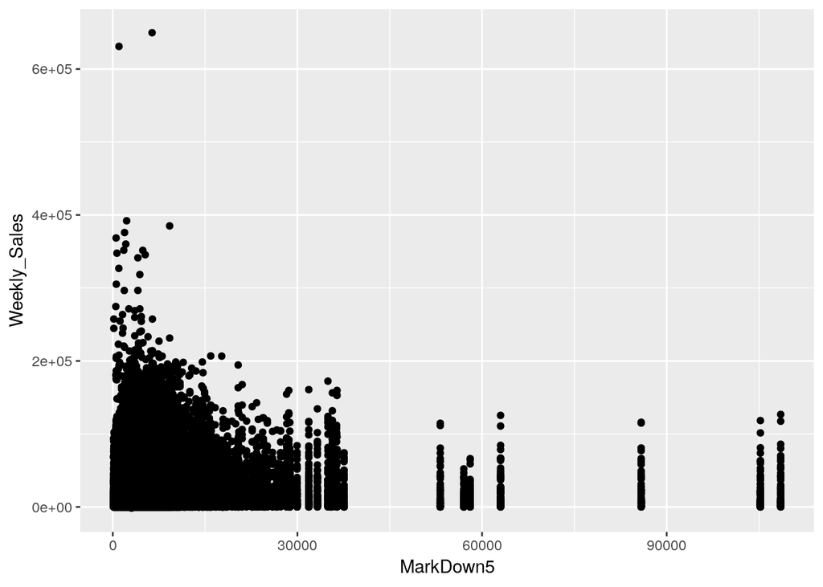

```r
ggplot(SM, aes(x=MarkDown5, y = Weekly_Sales)) + geom_point()
```

Drop MarkDown features and external features because of large NAs and no strong correlations with Weekly Sales

```r
#drop features
data_clean<- alldata %>% dplyr::select(-MarkDown1, -MarkDown2, -MarkDown3, -MarkDown4, -MarkDown5, -CPI, -Temperature, -Fuel_Price, -Unemployment)

#keep features: weekly sales(numeric), store (factor), dept (factor), Date, IsHoliday(logic), Week(numeric), Type(factor), Size (integer)
str(data_clean)
```

```
## 'data.frame':    421570 obs. of  8 variables:
##  $ Store       : Factor w/ 45 levels "1","2","3","4",..: 1 1 1 1 1 1 1 1 1 1 ...
##  $ Date        : Date, format: "2010-02-05" "2010-02-05" ...
##  $ IsHoliday   : logi  FALSE FALSE FALSE FALSE FALSE FALSE ...
##  $ Dept        : Factor w/ 81 levels "1","2","3","4",..: 1 25 16 44 27 65 53 5 55 7 ...
##  $ Weekly_Sales: num  24924.5 11737.1 13223.8 37.4 1085.3 ...
##  $ Type        : Factor w/ 3 levels "A","B","C": 1 1 1 1 1 1 1 1 1 1 ...
##  $ Size        : int  151315 151315 151315 151315 151315 151315 151315 151315 151315 151315 ...
##  $ Week        : num  5 5 5 5 5 5 5 5 5 5 ...
```

Prepare data set for model building

```r
#checking department-store level
# 3331 department-store levels
data_clean$DeptID<-as.factor(paste("D", data_clean$Dept, "S", data_clean$Store, sep=""))
str(data_clean[,"DeptID"])
```

```
##  Factor w/ 3331 levels "D10S1","D10S10",..: 399 714 271 1521 803 2445 1888 2057 1978 2490 ...
```

```r
#drop DeptID variable due to computation inefficiency
data_clean<-subset(data_clean, select = -c(DeptID))
str(data_clean)
```

```
## 'data.frame':    421570 obs. of  8 variables:
##  $ Store       : Factor w/ 45 levels "1","2","3","4",..: 1 1 1 1 1 1 1 1 1 1 ...
##  $ Date        : Date, format: "2010-02-05" "2010-02-05" ...
##  $ IsHoliday   : logi  FALSE FALSE FALSE FALSE FALSE FALSE ...
##  $ Dept        : Factor w/ 81 levels "1","2","3","4",..: 1 25 16 44 27 65 53 5 55 7 ...
##  $ Weekly_Sales: num  24924.5 11737.1 13223.8 37.4 1085.3 ...
##  $ Type        : Factor w/ 3 levels "A","B","C": 1 1 1 1 1 1 1 1 1 1 ...
##  $ Size        : int  151315 151315 151315 151315 151315 151315 151315 151315 151315 151315 ...
##  $ Week        : num  5 5 5 5 5 5 5 5 5 5 ...
```

```r
#aggregate sales to store sales
#data size: 45 store weekly sales data for 143 weeks
data_agg_store<-data_clean %>% group_by(Date, Store) %>% summarise(Store_Weekly_Sales = sum(Weekly_Sales)) %>%
  select(Date, Store, Store_Weekly_Sales)
head(data_agg_store)
```

```
## # A tibble: 6 x 3
## # Groups:   Date [1]
##   Date       Store Store_Weekly_Sales
##   <date>     <fct>              <dbl>
## 1 2010-02-05 1               1643691.
## 2 2010-02-05 2               2136989.
## 3 2010-02-05 3                461622.
## 4 2010-02-05 4               2135144.
## 5 2010-02-05 5                317173.
## 6 2010-02-05 6               1652635.
```

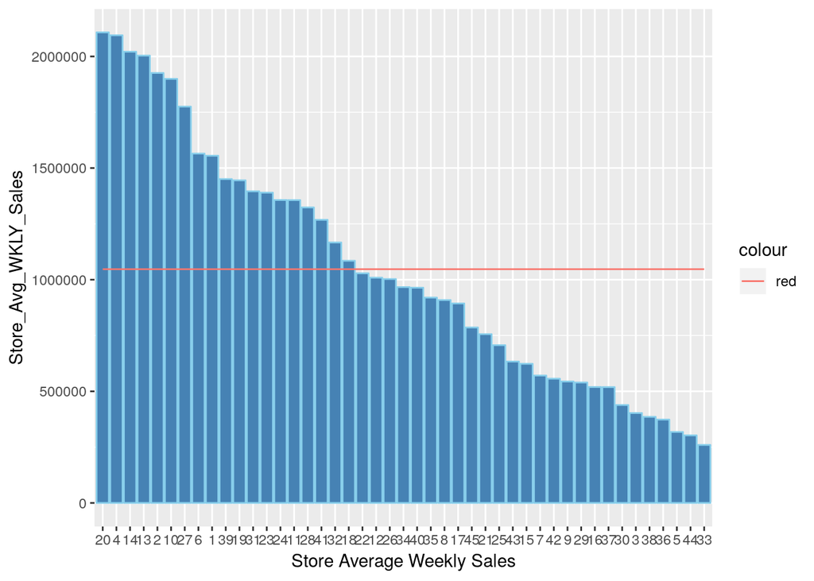

```r
#sort store average weekly sales by descending order and show all store average weekly sales in horizontal line
#store 18 represents the mean weekly sales
data_agg_store %>% group_by (Store) %>% summarise(Store_Avg_WKLY_Sales=mean(Store_Weekly_Sales)) %>% mutate(All_Store_Mean = mean(Store_Avg_WKLY_Sales)) %>%
 ggplot(aes(x=reorder(Store, -Store_Avg_WKLY_Sales), y=Store_Avg_WKLY_Sales)) + geom_col(color = "skyblue", fill = "steelblue")+geom_line(aes(x=Store, y= All_Store_Mean, group = 1, color = "red")) + xlab("Store Average Weekly Sales")
```

Decompose mean store weekly sales time series for trend and seasonality

```r
Store_mean<-alldata%>% group_by(Date) %>% summarise(Store_meanSales=sum(Weekly_Sales)/45)
Store_mean_ts<-ts(Store_mean[,-1], start = c(2010,5), end = c(2012, 43), frequency=52 )
frequency(Store_mean_ts)
```

```
## [1] 52
```

```r
class(Store_mean_ts)
```

```
## [1] "ts"
```

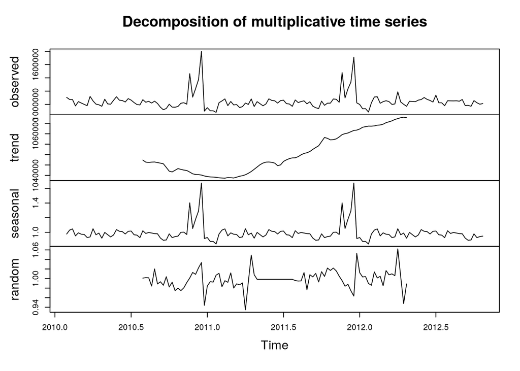

```r
plot(decompose(Store_mean_ts, type = ("multiplicative")))
```

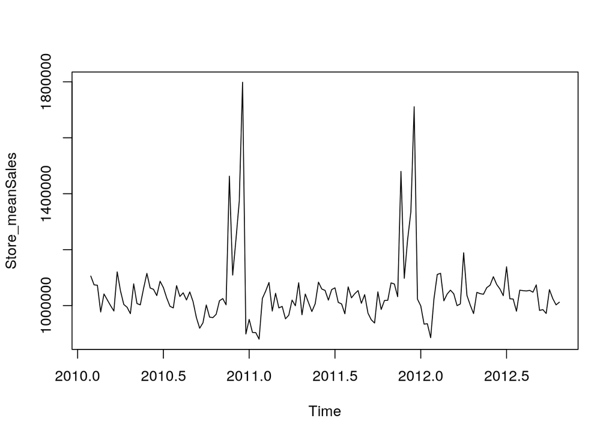

```r
#difference to detect trend and seasonality
plot(Store_mean_ts)
```

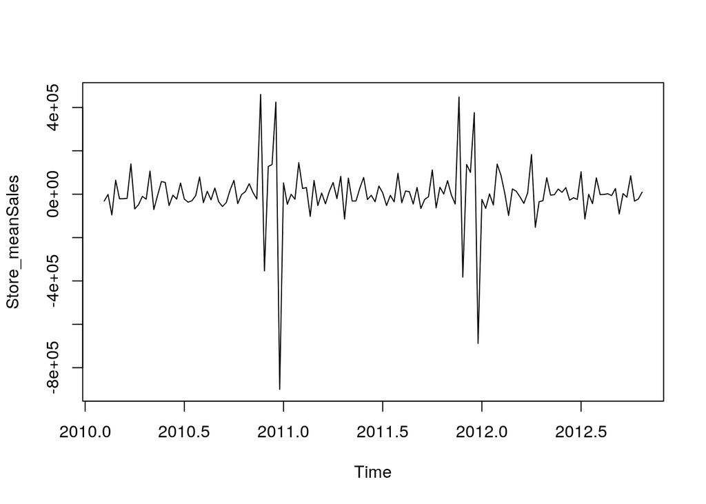

```r
plot(diff(Store_mean_ts))
```

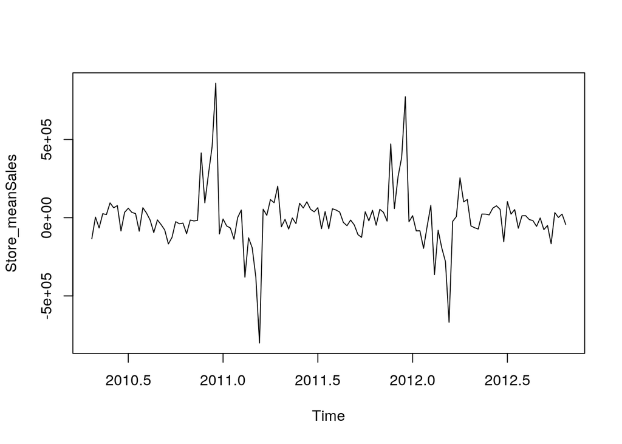

```r
plot(diff(Store_mean_ts, lag =12))
```

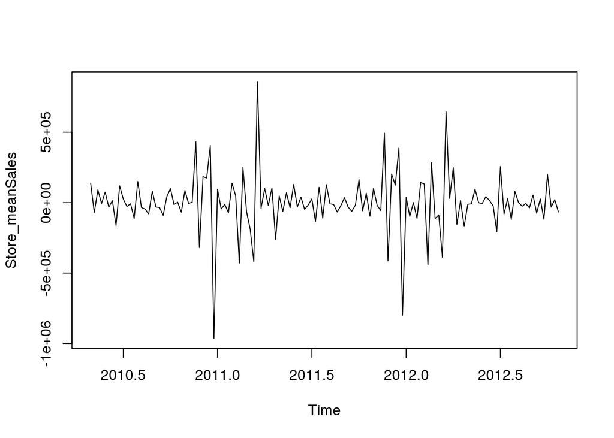

```r
plot(diff(diff(Store_mean_ts), lag = 12))
```

Split train/test sets by temporal point “2011-11-18”, about 65/35 split by week numbers

```r
train<- data_agg_store%>% filter (Date < "2011-11-18")
test<-data_agg_store %>% filter (Date >= "2011-11-18")
summary(train)
```

```
##       Date                Store      Store_Weekly_Sales
##  Min.   :2010-02-05   1      :  93   Min.   : 209986
##  1st Qu.:2010-07-16   2      :  93   1st Qu.: 545251
##  Median :2010-12-24   3      :  93   Median : 953393
##  Mean   :2010-12-24   4      :  93   Mean   :1036075
##  3rd Qu.:2011-06-03   5      :  93   3rd Qu.:1403779
##  Max.   :2011-11-11   6      :  93   Max.   :3818686
##                       (Other):3627
```

```r
summary(test)
```

```
##       Date                Store      Store_Weekly_Sales
##  Min.   :2011-11-18   1      :  50   Min.   : 215359
##  1st Qu.:2012-02-10   2      :  50   1st Qu.: 566278
##  Median :2012-05-07   3      :  50   Median : 976404
##  Mean   :2012-05-07   4      :  50   Mean   :1067219
##  3rd Qu.:2012-08-03   5      :  50   3rd Qu.:1460906
##  Max.   :2012-10-26   6      :  50   Max.   :3676389
##                       (Other):1950
```

```r
#create wide form  data
trainwide<-dcast(train,Date~Store, fun.aggregate = sum, value.var = "Store_Weekly_Sales") %>% select(-"Date")
testwide<-dcast(test, Date~Store, fun.aggregate = sum, value.var = "Store_Weekly_Sales") %>%select(-"Date")

#create ts data
train_ts<-ts(trainwide[,c(1:45)], start = c(2010,5), end=c(2011,45), frequency = 52)
test_ts<-ts(testwide[,c(1:45)], start = c(2011,46), end = c(2012,43), frequency = 52)
alldata_ts<-ts(rbind(train_ts, test_ts), start = c(2010,5), end = c(2012,43), frequency = 52)
```

Build seasonal auto.arima model

```r
#fit seasonal auto.arima model; use D=1 due to limited data
arm_fit<-list()
for (i in colnames(train_ts)){
  arm_fit[[i]]<-auto.arima(train_ts[,i], D = 1, lambda=0, stepwise = FALSE, approximation = 93, seasonal.test = "seas")
}
#show fit example
arm_fit[[18]]
```

```
## Series: train_ts[, i]
## ARIMA(0,0,0)(0,1,0)[52] with drift
## Box Cox transformation: lambda= 0
##
## Coefficients:
##         drift
##       -0.0023
## s.e.   0.0004
##
## sigma^2 estimated as 0.01554:  log likelihood=28.03
## AIC=-52.06   AICc=-51.75   BIC=-48.64
```

```r
#forecast
arm_fcast<-list()
for (i in colnames(train_ts)){
  arm_fcast[[i]]<-forecast(arm_fit[[i]], h = 50)
}

#show forecast example
arm_fcast[[18]]
```

```
##          Point Forecast     Lo 80     Hi 80     Lo 95     Hi 95
## 2011.865       927881.3  790864.4 1088636.3  726723.1 1184720.4
## 2011.885      1467399.4 1250713.8 1721625.6 1149277.5 1873578.0
## 2011.904      1074557.2  915881.2 1260723.7  841600.7 1371996.4
## 2011.923      1256582.7 1071027.7 1474285.1  984164.4 1604406.9
## 2011.942      1409432.5 1201306.7 1653616.0 1103877.4 1799565.8
## 2011.962      1799030.0 1533373.7 2110711.1 1409012.9 2297004.5
## 2011.981       787849.9  671511.0  924344.6  617049.6 1005928.1
## 2012.000       828713.5  706340.4  972287.8  649054.2 1058102.8
## 2012.019       689596.4  587766.2  809068.7  540096.7  880477.8
## 2012.038       790726.2  673962.5  927719.1  619302.3 1009600.5
## 2012.058       753807.2  642495.2  884403.9  590387.1  962462.3
## 2012.077       936859.9  798517.1 1099170.4  733755.2 1196184.2
## 2012.096       995610.8  848592.6 1168099.9  779769.4 1271197.6
## 2012.115       971657.8  828176.6 1139997.1  761009.2 1240614.4
## 2012.135       892620.4  760810.3 1047266.4  699106.5 1139699.2
## 2012.154       943487.5  804166.1 1106946.3  738946.0 1204646.4
## 2012.173       889719.7  758338.0 1043863.2  696834.7 1135995.6
## 2012.192       839298.5  715362.3  984706.6  657344.5 1071617.7
## 2012.212       838086.2  714329.0  983284.2  656395.0 1070069.9
## 2012.231       832371.8  709458.5  976579.8  651919.4 1062773.7
## 2012.250       903763.2  770307.8 1060339.8  707833.7 1153926.4
## 2012.269       876803.5  747329.1 1028709.3  686718.6 1119504.2
## 2012.288       981242.1  836345.6 1151241.9  768515.7 1252851.6
## 2012.308       864342.7  736708.3 1014089.7  676959.3 1103594.2
## 2012.327       945365.7  805767.0 1109149.9  740417.1 1207044.6
## 2012.346       881253.6  751122.1 1033930.4  690204.0 1125186.1
## 2012.365       882529.1  752209.2 1035426.8  691202.9 1126814.6
## 2012.385       945176.5  805605.7 1108927.9  740268.9 1206803.0
## 2012.404      1045287.3  890933.5 1226382.8  818676.3 1334624.6
## 2012.423       926423.3  789621.7 1086925.7  725581.2 1182858.8
## 2012.442       928002.9  790968.0 1088778.9  726818.3 1184875.6
## 2012.462       937425.4  798999.2 1099834.0  734198.2 1196906.4
## 2012.481       964552.9  822120.8 1131661.2  755444.6 1231542.7
## 2012.500       930614.4  793193.9 1091842.9  728863.7 1188210.0
## 2012.519       865054.1  737314.7 1014924.3  677516.4 1104502.5
## 2012.538       879558.4  749677.2 1031941.5  688876.3 1123021.6
## 2012.558       846626.9  721608.5  993304.6  663084.1 1080974.6
## 2012.577       889801.4  758407.7 1043959.1  696898.7 1136100.0
## 2012.596       823842.7  702188.8  966573.0  645239.3 1051883.7
## 2012.615       827577.3  705372.0  970954.7  648164.3 1056652.1
## 2012.635      1018550.4  868144.7 1195013.7  797735.8 1300486.8
## 2012.654       479967.0  409092.0  563121.1  375913.5  612822.7
## 2012.673       844320.7  719642.9  990598.9  661277.9 1078030.1
## 2012.692       750412.8  639602.1  880421.5  587728.6  958128.3
## 2012.712       756941.5  645166.6  888081.2  592841.9  966464.1
## 2012.731       751861.5  640836.8  882121.2  588863.2  959978.0
## 2012.750       904827.8  771215.1 1061588.8  708667.5 1155285.6
## 2012.769       846081.4  721143.7  992664.7  662656.9 1080278.2
## 2012.788       930090.9  792747.7 1091228.7  728453.7 1187541.6
## 2012.808       981936.5  836937.5 1152056.5  769059.5 1253738.2
```

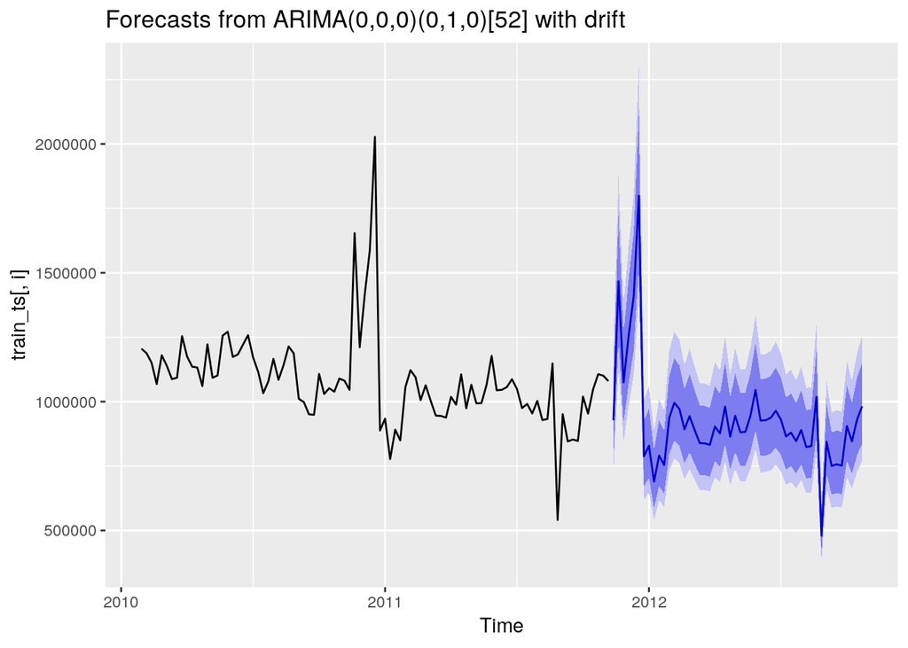

```r
autoplot(arm_fcast[[18]])
```

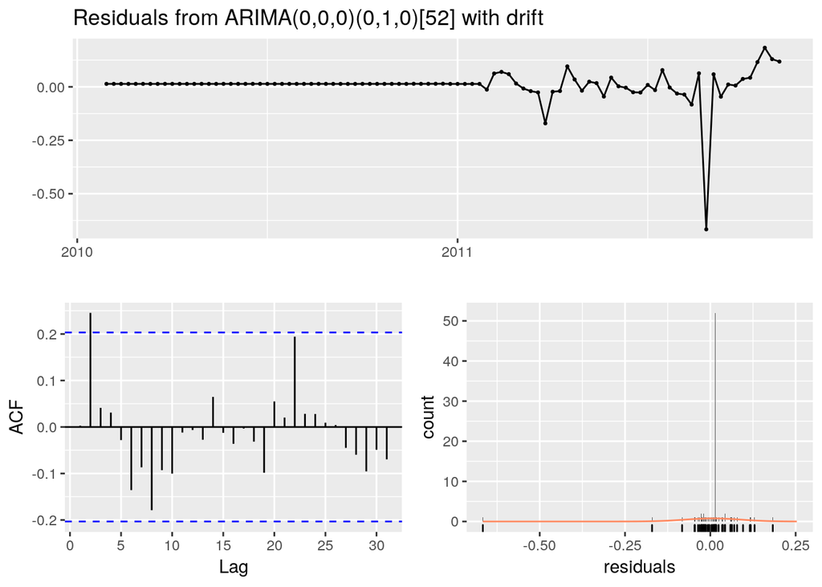

```
##
##  Ljung-Box test
##
## data:  Residuals from ARIMA(0,0,0)(0,1,0)[52] with drift
## Q* = 16.149, df = 18, p-value = 0.5821
##
## Model df: 1.   Total lags used: 19
```

```r
checkresiduals(arm_fcast[[18]])
```

```r
#validation
arm_accuracy<-list()
for (i in names(arm_fcast)){
  arm_accuracy[[i]]<-accuracy(arm_fcast[[i]], test_ts[,i])
}
#show validation example
arm_accuracy[[18]]
```

```
##                     ME      RMSE       MAE       MPE      MAPE      MASE
## Training set  10735.43  69479.35  35004.78  0.386516  3.794527 0.2766449
## Test set     164612.32 185111.73 164612.32 15.372700 15.372700 1.3009413
##                    ACF1 Theil's U
## Training set 0.04407112        NA
## Test set     0.13821099  1.227682
```

```r
#calculate arima model accuracy
sum_arm_MAE<-0
sum_arm_MAPE<-0
sum_arm_RMSE<-0

for (i in 1:45){

  sum_arm_MAE<-arm_accuracy[[i]][2,3]+sum_arm_MAE
  arm_MAE<-sum_arm_MAE/45
  sum_arm_MAPE<-arm_accuracy[[i]][2,5]+sum_arm_MAPE
  arm_MAPE<-sum_arm_MAPE/45
  sum_arm_RMSE<-arm_accuracy[[i]][2,2]+sum_arm_RMSE
  arm_RMSE<-sum_arm_RMSE/45
  }
#arima model accuracy
arm_MAE
```

```
## [1] 61988.33
```

```r
arm_MAPE
```

```
## [1] 5.760323
```

```r
arm_RMSE
```

```
## [1] 78263.48
```

Random Forst model using “ranger”

```r
#build random forest model on training set
train_rf<-data_clean %>% filter(Date <"2011-11-18") %>%
  group_by (Date, Store,IsHoliday, Week, Type ) %>% summarize (Store_Weekly_Sales = sum(Weekly_Sales))
test_rf<-data_clean %>% filter(Date >="2011-11-18") %>%
  group_by (Date, Store,IsHoliday, Week, Type ) %>% summarize (Store_Weekly_Sales = sum(Weekly_Sales))
seed<-set.seed(10)

outcome<-"train_rf$Store_Weekly_Sales"
vars<-c("Store", "Week", "Type", "IsHoliday")
fmla<-paste(outcome, "~", paste(vars, collapse = "+"))
fit_rf<-ranger(fmla,train_rf, num.trees = 500, respect.unordered.factors = "order", seed = seed)

#fit error
fit_rf$prediction.error
```

```
## [1] 8445936600
```

```r
fit_rf$r.squared
```

```
## [1] 0.9728368
```

```r
#predict on test set
test_rf$pred<-predict(fit_rf, test_rf)$predictions

#calculate random forest model MAE
test_rf %>% mutate (residual = Store_Weekly_Sales-pred) %>%
  group_by(Store) %>%
  summarize (rf_MAE_store = (mean(abs(residual)))) %>%
  summarize(rf_MAE = mean(rf_MAE_store)) %>% print()
```

```
## # A tibble: 1 x 1
##   rf_MAE
##    <dbl>
## 1 70209.
```

```r
#calculate random forest model MAPE
test_rf %>% mutate (residual = Store_Weekly_Sales-pred) %>%
  group_by(Store) %>%
  summarize (rf_MAPE_store = (mean(abs(residual/Store_Weekly_Sales)*100))) %>%
  summarize(rf_MAPE = mean(rf_MAPE_store)) %>% print()
```

```
## # A tibble: 1 x 1
##   rf_MAPE
##     <dbl>
## 1    7.29
```

```r
#calculate random forest model RMSE
test_rf %>% mutate(residual = Store_Weekly_Sales-pred) %>%
  group_by(Store) %>%
  summarize(rf_RMSE_store = (mean(residual^2))^0.5) %>%
  summarize(rf_RMSE=mean(rf_RMSE_store)) %>% print()
```

```
## # A tibble: 1 x 1
##   rf_RMSE
##     <dbl>
## 1  86753.
```

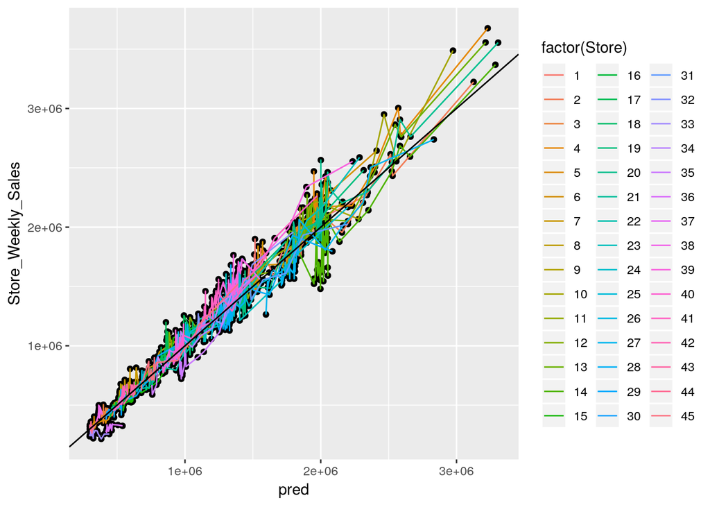

```r
#plot random forest prediction
ggplot(test_rf, aes(x= pred, y=Store_Weekly_Sales))+
  geom_point()+
  geom_line(aes(color = factor(Store)))+
  geom_abline()
```

XGBoost Tree Model

```r
#data prep using "vtreat"

#create one hot encoding plan
treatplan<-designTreatmentsZ(train_rf, vars, verbose = F)

#querry new varName
newvars<-treatplan %>%
  magrittr::use_series(scoreFrame) %>%
  filter(code %in% c("clean", "lev")) %>%
  magrittr::use_series(varName)

#prepare train/test set
train_rf_treat<-prepare(treatplan, train_rf, varRestriction = newvars)
test_rf_treat<-prepare(treatplan, test_rf, varRestriction = newvars)


#xgboost cross validation on training set
cv<-xgb.cv(data=as.matrix(train_rf_treat), label = train_rf$Store_Weekly_Sales,
           nrounds = 100, nfold = 10, max_depth = 6, eta = 0.3,
           objective = "reg:linear", early_stopping_rounds = 10)
```

[output not shown]

```r
#evaluation
elog<- cv$evaluation_log %>%
  summarize(ntrees.train = which.min(train_rmse_mean), ntrees.test = which.min(test_rmse_mean))
elog
```

```
##   ntrees.train ntrees.test
## 1           84          74
```

```r
nrounds <-88

#fit xgboost model
fit_xgb<-xgboost(data=as.matrix(train_rf_treat), label = train_rf$Store_Weekly_Sales,
                 nrounds = nrounds, max_depth = 6, eta = 0.3,
                 objective = "reg:linear")
```

```
## [18:59:25] WARNING: amalgamation/../src/objective/regression_obj.cu:170: reg:linear is now deprecated in favor of reg:squarederror.
```

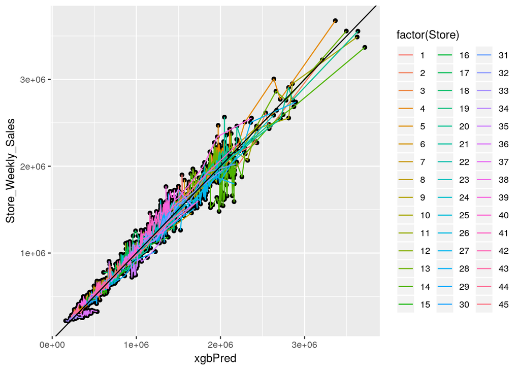

```r
#predict test set
test_rf$xgbPred<-predict(fit_xgb, as.matrix(test_rf_treat))

#plot prediction vs. test set
ggplot(test_rf, aes(x= xgbPred, y=Store_Weekly_Sales))+
  geom_point()+
  geom_line(aes(color = factor(Store)))+
  geom_abline()
```

```r
#calculate xgboost model MAE
test_rf %>% mutate (xgbResidual = Store_Weekly_Sales-xgbPred) %>%
  group_by(Store) %>%
  summarize (xgbMAE_store = (mean(abs(xgbResidual)))) %>%
  summarize(xgbMAE = mean(xgbMAE_store)) %>% print()
```

```
## # A tibble: 1 x 1
##   xgbMAE
##    <dbl>
## 1 66535.
```

```r
#Calculate xgboost model MAPE
test_rf %>% mutate (xgbResidual = Store_Weekly_Sales-xgbPred) %>%
  group_by(Store) %>%
  summarize (xgbMAPE_store = (mean(abs(xgbResidual/Store_Weekly_Sales)*100))) %>%
  summarize(xgbMAPE = mean(xgbMAPE_store)) %>% print()
```

```
## # A tibble: 1 x 1
##   xgbMAPE
##     <dbl>
## 1    6.92
```

```r
#Calculate xgboost model RMSE
test_rf %>% mutate (xgbResidual = Store_Weekly_Sales-xgbPred) %>%
  group_by(Store) %>%
  summarize (xgbRMSE_store = (mean(xgbResidual^2))^0.5) %>%
  summarize(xgbRMSE = mean(xgbRMSE_store)) %>% print()
```

```
## # A tibble: 1 x 1
##   xgbRMSE
##     <dbl>
## 1  80961.
```

Build Neural Network Model

```r
#prepare data
#use train_ts and test_ts

#fit nnetar
nn_fit<-list()
for (i in colnames(train_ts)) {
 nn_fit[[i]]<-nnetar(train_ts[,i], p=52, P=1, repeats = 20, size = 5,  trace = F)
}
#show fit example
nn_fit[[18]]
```

```
## Series: train_ts[, i]
## Model:  NNAR(52,1,5)[52]
## Call:   nnetar(y = train_ts[, i], p = 52, P = 1, size = 5, repeats = 20,
##     trace = F)
##
## Average of 20 networks, each of which is
## a 52-5-1 network with 271 weights
## options were - linear output units
##
## sigma^2 estimated as 785930
```

```r
#forecast
nn_fcast<-list()
for (i in colnames(train_ts)){
  nn_fcast[[i]]<-forecast(nn_fit[[i]], h=50)
}

#show forecast example
nn_fcast[18]
```

```
## $`18`
##          Point Forecast
## 2011.865       987309.1
## 2011.885      1032202.4
## 2011.904       973111.1
## 2011.923      1012352.9
## 2011.942       971841.5
## 2011.962      1072455.8
## 2011.981       799813.0
## 2012.000       932379.9
## 2012.019       907692.7
## 2012.038       927586.4
## 2012.058       818025.1
## 2012.077      1096738.9
## 2012.096       801366.6
## 2012.115       863568.5
## 2012.135       920621.8
## 2012.154       899897.1
## 2012.173       779846.8
## 2012.192       864373.8
## 2012.212       860026.4
## 2012.231       818569.8
## 2012.250       961804.4
## 2012.269       911183.1
## 2012.288       935472.7
## 2012.308      1022185.2
## 2012.327       792779.7
## 2012.346      1014726.7
## 2012.365       947142.0
## 2012.385       962952.5
## 2012.404       846728.6
## 2012.423      1095654.1
## 2012.442       826446.1
## 2012.462       976993.6
## 2012.481       917846.9
## 2012.500       852276.8
## 2012.519       825556.6
## 2012.538       784802.1
## 2012.558       788928.6
## 2012.577       783983.0
## 2012.596       853696.2
## 2012.615       795959.5
## 2012.635       904185.5
## 2012.654       774126.0
## 2012.673       907708.2
## 2012.692       880138.6
## 2012.712       934223.3
## 2012.731       769507.0
## 2012.750      1063267.2
## 2012.769       820356.5
## 2012.788       897695.1
## 2012.808       911042.5
```

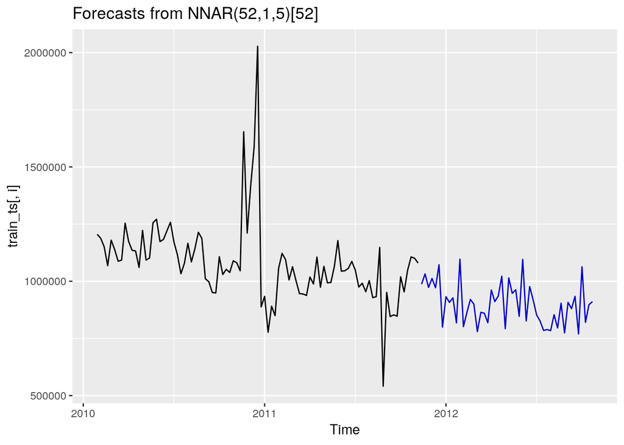

```r
autoplot(forecast(nn_fit[[18]], h = 50))
```

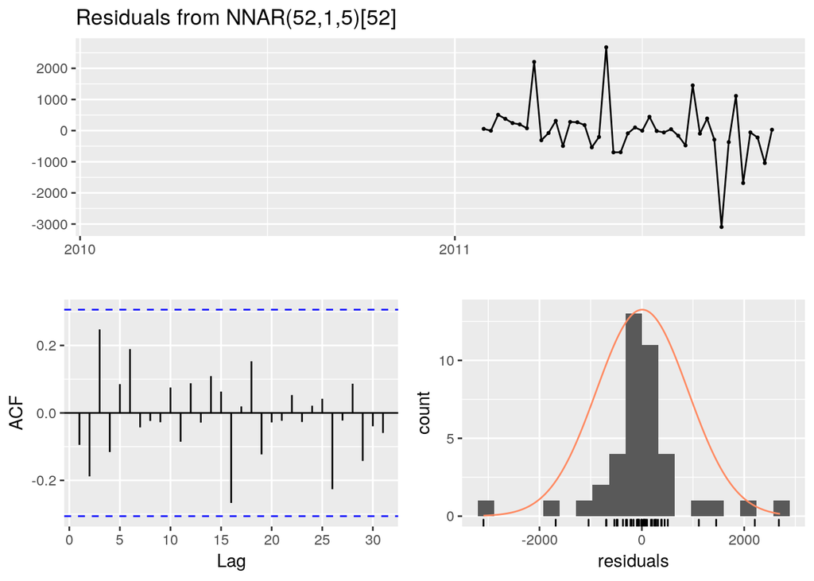

```r
checkresiduals(nn_fcast[[18]])
```

```r
#validation
nn_accuracy<-list()
for (i in names(nn_fcast)) {
  nn_accuracy[[i]]<-accuracy(nn_fcast[[i]], test_ts[,i])
}
#show accuracy example
nn_accuracy[[18]]
```

```
##                        ME        RMSE         MAE          MPE        MAPE
## Training set 7.184124e+00    886.5269    527.4884 -0.002138368  0.05303551
## Test set     1.893398e+05 246973.1213 194360.9546 16.174198951 16.68592867
##                     MASE        ACF1 Theil's U
## Training set 0.004168773 -0.09482652        NA
## Test set     1.536046562  0.26589395  1.523289
```

```r
#calculate nn model accuracy
sum_nn_MAE<-0
sum_nn_MAPE<-0
sum_nn_RMSE<-0

for (i in 1:45){

  sum_nn_MAE<-nn_accuracy[[i]][2,3]+sum_nn_MAE
  nn_MAE<-sum_nn_MAE/45
  sum_nn_MAPE<-nn_accuracy[[i]][2,5]+sum_nn_MAPE
  nn_MAPE<-sum_nn_MAPE/45
  sum_nn_RMSE<-nn_accuracy[[i]][2,2]+sum_nn_RMSE
  nn_RMSE<-sum_nn_RMSE/45
  }
#neural network model accuracy
nn_MAE
```

```
## [1] 98224.32
```

```r
nn_MAPE
```

```
## [1] 8.369956
```

```r
nn_RMSE
```

```
## [1] 152123.6
```